# РК1 Ищенко А.С. ИУ5-65Б Вар.6

## РК №1

##### Рубежный контроль №1. Ищенко А.С. Вариант №6: задание 1, датасет 6

### Задание:

Для заданного набора данных проведите корреляционный анализ. В случае наличия пропусков в данных удалите строки или колонки, содержащие пропуски. Сделайте выводы о возможности построения моделей машинного обучения и о возможном вкладе признаков в модель.

Набор данных состоит из данных, необходимых для прогнозирования поступления в аспирантуру в Индии. Набор содержит следующие данные:

Баллы GRE (из 340) Баллы TOEFL (из 120) Рейтинг университета ( из 5 ) Заявление о целях (из 5) Рекомендательное письмо (из 5) Средний балл бакалавриата (из 10) Исследовательский опыт (0 или 1) Шанс допуска (от 0 до 1)

```python
import numpy as np
import pandas as pd
import seaborn as sns
import matplotlib.pyplot as plt
from sklearn.model_selection import train_test_split
from sklearn.neighbors import KNeighborsRegressor, KNeighborsClassifier

from sklearn.model_selection import GridSearchCV
from sklearn.metrics import f1_score
from sklearn.preprocessing import OrdinalEncoder
from sklearn import preprocessing
from sklearn import utils

%matplotlib inline
sns.set(style="ticks")
```

```python
df = pd.read_csv('Admission_Predict_Ver1.1.csv')
```

```python
df.shape
```

```
(500, 9)
```

```python
df.head(5)
```

|  | Serial No. | GRE Score | TOEFL Score | University Rating | SOP | LOR | CGPA | Research | Chance of Admit |
| --- | --- | --- | --- | --- | --- | --- | --- | --- | --- |
| 0 | 1 | 337 | 118 | 4 | 4.5 | 4.5 | 9.65 | 1 | 0.92 |
| 1 | 2 | 324 | 107 | 4 | 4.0 | 4.5 | 8.87 | 1 | 0.76 |
| 2 | 3 | 316 | 104 | 3 | 3.0 | 3.5 | 8.00 | 1 | 0.72 |
| 3 | 4 | 322 | 110 | 3 | 3.5 | 2.5 | 8.67 | 1 | 0.80 |
| 4 | 5 | 314 | 103 | 2 | 2.0 | 3.0 | 8.21 | 0 | 0.65 |

```python
df.columns
```

```
Index(['Serial No.', 'GRE Score', 'TOEFL Score', 'University Rating', 'SOP',
       'LOR ', 'CGPA', 'Research', 'Chance of Admit '],
      dtype='object')
```

Название последней колонки имеет незаметный лишний пробел в конце строки, уберем его

```python
df.rename(columns={'Chance of Admit ': 'Chance of Admit'}, inplace=True)
```

```python
df.columns
```

```
Index(['Serial No.', 'GRE Score', 'TOEFL Score', 'University Rating', 'SOP',
       'LOR ', 'CGPA', 'Research', 'Chance of Admit'],
      dtype='object')
```

```python
df.info()
```

```
<class 'pandas.core.frame.DataFrame'>
RangeIndex: 500 entries, 0 to 499
Data columns (total 9 columns):
 #   Column             Non-Null Count  Dtype
---  ------             --------------  -----
 0   Serial No.         500 non-null    int64
 1   GRE Score          500 non-null    int64
 2   TOEFL Score        500 non-null    int64
 3   University Rating  500 non-null    int64
 4   SOP                500 non-null    float64
 5   LOR                500 non-null    float64
 6   CGPA               500 non-null    float64
 7   Research           500 non-null    int64
 8   Chance of Admit    500 non-null    float64
dtypes: float64(4), int64(5)
memory usage: 35.3 KB
```

```python
df.dtypes
```

```
Serial No.             int64
GRE Score              int64
TOEFL Score            int64
University Rating      int64
SOP                  float64
LOR                  float64
CGPA                 float64
Research               int64
Chance of Admit      float64
dtype: object
```

```python
print('Число пропусков')
df.isna().sum()
```

```
Число пропусков
```

```
Serial No.           0
GRE Score            0
TOEFL Score          0
University Rating    0
SOP                  0
LOR                  0
CGPA                 0
Research             0
Chance of Admit      0
dtype: int64
```

## Визуализация данных

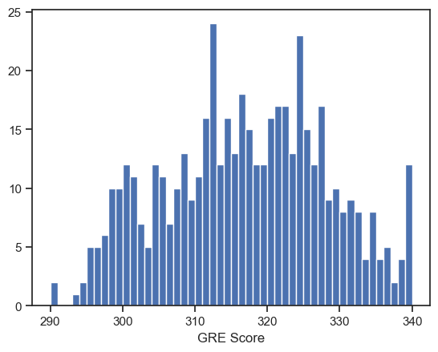

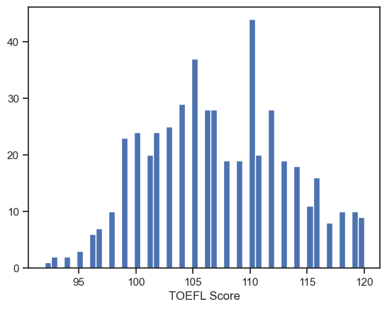

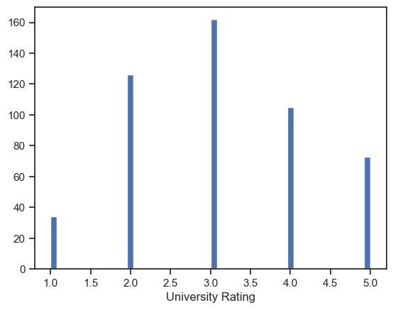

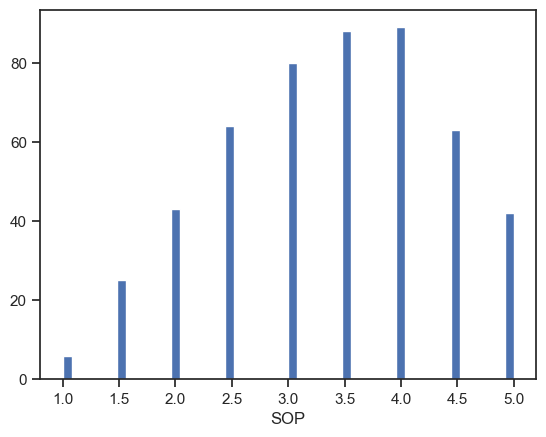

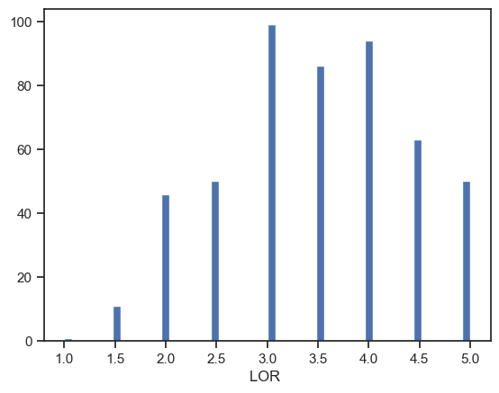

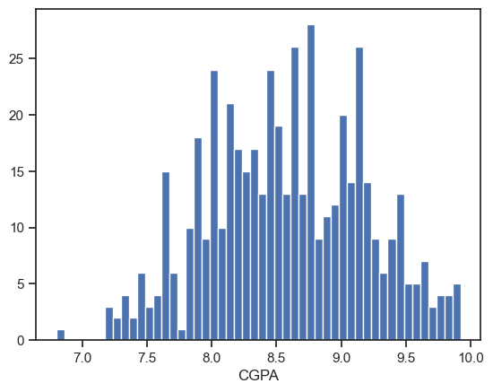

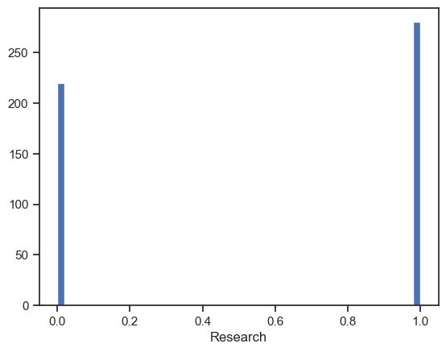

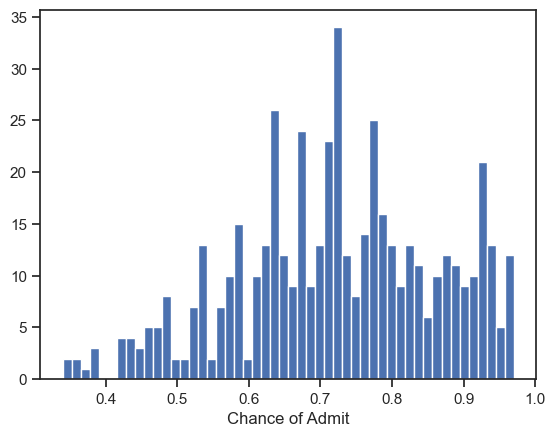

```python
df_new = df.drop(columns='Serial No.')

for column in df_new:
    plt.hist(df_new[column], 50)
    plt.xlabel(column)
    plt.show()
```

### Парный анализ

Все данные в наборе являются числовыми, поэтому в подготовке для парного анализа не нуждаются

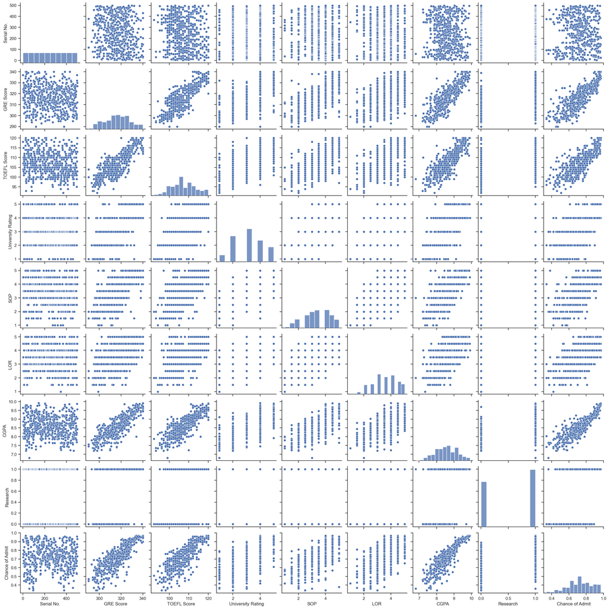

```python
sns.pairplot(df)
```

### Тепловая карта

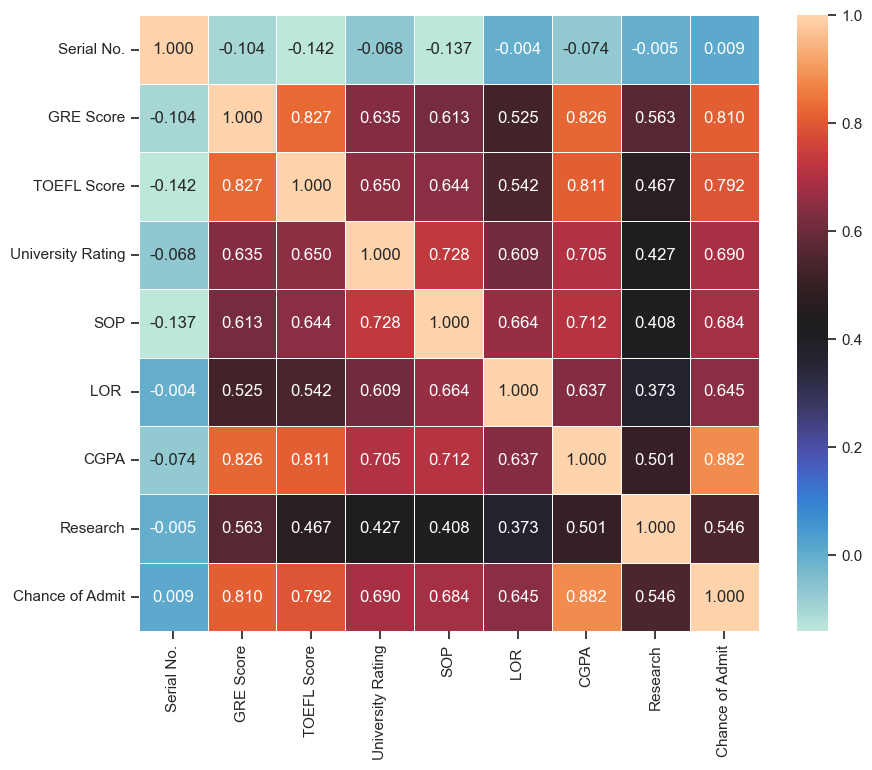

```python
f,ax = plt.subplots(figsize=(10, 8))
sns.heatmap(df.corr(), annot=True, linewidths=.5, fmt= '.3f',ax=ax,cmap="icefire");
```

По тепловой карте видно, что такие признаки, как CGPA, Баллы GRE и TOEFL сильно коррелируют с шансом поступления. На основании этого можно сделать модель предсказания шанса поступления судя по этим параметрам.

Для этого можно использовать классифкацию (или регрессию) на основе метода k-ближайших соседей (также можно использовать SVM и дерево решений).

Найдем наилучшее количество соседей для метода k-ближайших соседей

```python
data_train, data_test, train_target, test_target = train_test_split(df, df['Chance of Admit'], test_size=0.1, random_state=42)
dtest = data_test[['GRE Score','University Rating', 'Chance of Admit']]

lab = preprocessing.LabelEncoder()
test_target_transformed = lab.fit_transform(test_target)

knn = KNeighborsClassifier()
parametrs = {'n_neighbors': range(1, 10)}
grid = GridSearchCV(knn, parametrs, cv=4, scoring='f1')
grid.fit(dtest, test_target_transformed)
grid.best_params_
```

```
{'n_neighbors': 1}
```